# Model application

```r
extinct <- read.csv("model_data2.csv")
extant <- read.csv("living_data2.csv")
```

## Data description

```r
nrow(na.omit(extant))
```

```
## [1] 261
```

```r
summary(extant)
```

```
##       X.1               X                              species
##  Min.   :   1.0   Min.   :   1.0   Lyciasalamandra luschani:   2
##  1st Qu.: 492.8   1st Qu.: 492.8   Salamandra algira       :   2
##  Median : 984.5   Median : 984.5   Salamandrina terdigitata:   2
##  Mean   : 984.5   Mean   : 984.5   Acanthixalus spinosus   :   1
##  3rd Qu.:1476.2   3rd Qu.:1476.2   Acris blanchardi        :   1
##  Max.   :1968.0   Max.   :1968.0   Acris crepitans         :   1
##                                    (Other)                 :1959
##       SVL              count            abu_cat       lat.range
##  Min.   :0.00000   Min.   :   1.00   Min.   :1.00   Min.   : 0.00201
##  1st Qu.:0.01829   1st Qu.:   3.00   1st Qu.:1.00   1st Qu.: 0.52441
##  Median :0.03027   Median :  13.00   Median :3.00   Median : 3.03725
##  Mean   :0.04004   Mean   : 110.11   Mean   :2.52   Mean   : 6.88834
##  3rd Qu.:0.05042   3rd Qu.:  42.25   3rd Qu.:3.00   3rd Qu.: 9.83493
##  Max.   :1.00000   Max.   :5037.00   Max.   :4.00   Max.   :86.89850
##  NA's   :4         NA's   :1628      NA's   :565    NA's   :181
##  maxGCD_extant        mean_lat          min_lat         Red.List.status
##  Min.   :    0.0   Min.   :-44.193   Min.   :-47.2900   LC     :817
##  1st Qu.:  111.3   1st Qu.:-12.796   1st Qu.:-16.5850   EN     :257
##  Median :  446.4   Median :  2.404   Median : -1.5200   CR     :186
##  Mean   : 1098.5   Mean   :  2.756   Mean   : -0.7929   VU     :182
##  3rd Qu.: 1415.4   3rd Qu.: 14.528   3rd Qu.: 10.9100   DD     :169
##  Max.   :20038.3   Max.   : 58.855   Max.   : 45.2100   (Other):138
##  NA's   :181       NA's   :181       NA's   :181        NA's   :219
##      Order               Family                  Genus         hab.cat
##  ANURA  :1664   BUFONIDAE   :192   Hyperolius       :  91   high   : 12
##  CAUDATA:  85   MANTELLIDAE :170   Eleutherodactylus:  75   highlow:880
##  NA's   : 219   HYPEROLIIDAE:160   Phrynobatrachus  :  66   low    :453
##                 HYLIDAE     :141   Atelopus         :  63   NA's   :623
##                 MICROHYLIDAE: 92   Boophis          :  57
##                 (Other)     :994   (Other)          :1397
##                 NA's        :219   NA's             : 219
```

```r
extant <- extant[, colnames(extant) != "count"]
extant$complete_case <- complete.cases(extant)
ext <- na.omit(extant)
ext <- droplevels(ext)
summary(ext)
```

```
##       X.1               X                                species
##  Min.   :   3.0   Min.   :   3.0   Salamandra algira         :   2
##  1st Qu.: 458.5   1st Qu.: 458.5   Salamandrina terdigitata  :   2
##  Median : 993.0   Median : 993.0   Acris crepitans           :   1
##  Mean   : 969.1   Mean   : 969.1   Acris gryllus             :   1
##  3rd Qu.:1400.5   3rd Qu.:1400.5   Adelphobates castaneoticus:   1
##  Max.   :1965.0   Max.   :1965.0   Adenomera andreae         :   1
##                                    (Other)                   :1083
##       SVL              abu_cat        lat.range        maxGCD_extant
##  Min.   :0.002831   Min.   :1.000   Min.   : 0.00248   Min.   :    0.0
##  1st Qu.:0.019384   1st Qu.:1.000   1st Qu.: 1.49181   1st Qu.:  232.5
##  Median :0.031907   Median :3.000   Median : 4.92236   Median :  741.0
##  Mean   :0.041607   Mean   :2.541   Mean   : 8.86482   Mean   : 1408.3
##  3rd Qu.:0.051222   3rd Qu.:3.000   3rd Qu.:12.21124   3rd Qu.: 1913.9
##  Max.   :0.969509   Max.   :4.000   Max.   :86.89850   Max.   :20038.3
##
##     mean_lat          min_lat        Red.List.status     Order
##  Min.   :-44.193   Min.   :-47.290   LC     :642     ANURA  :1051
##  1st Qu.:-13.943   1st Qu.:-18.685   EN     :121     CAUDATA:  40
##  Median :  2.709   Median : -1.860   VU     :111
##  Mean   :  2.820   Mean   : -1.755   CR     : 86
##  3rd Qu.: 13.918   3rd Qu.:  9.485   NT     : 76
##  Max.   : 58.855   Max.   : 45.210   DD     : 48
##                                      (Other):  7
##             Family                Genus        hab.cat    complete_case
##  HYPEROLIIDAE  :125   Hyperolius     : 65   high   :  9   Mode:logical
##  BUFONIDAE     :124   Boophis        : 49   highlow:702   TRUE:1091
##  MANTELLIDAE   :122   Phrynobatrachus: 45   low    :380   NA's:0
##  HYLIDAE       :108   Atelopus       : 43
##  RANIDAE       : 61   Leptopelis     : 36
##  ARTHROLEPTIDAE: 53   Afrixalus      : 24
##  (Other)       :498   (Other)        :829
```

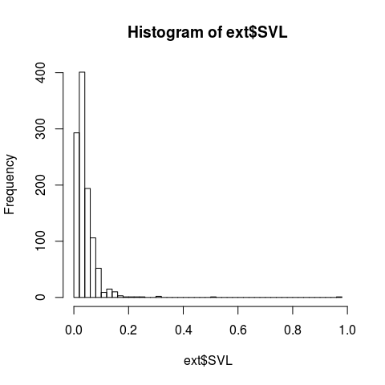

```r
hist(ext$SVL, breaks = 40)
```

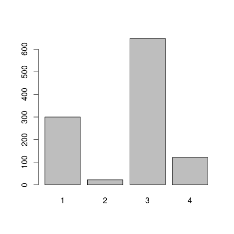

```r
barplot(table(ext$abu_cat))
```

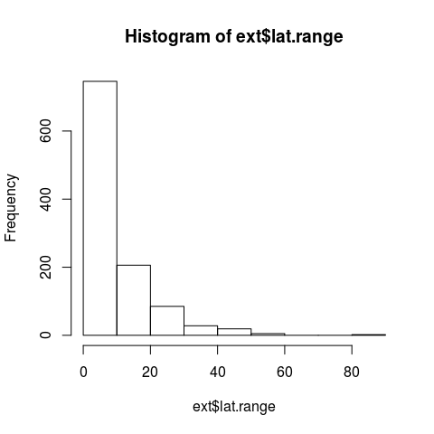

```r
hist(ext$lat.range)
```

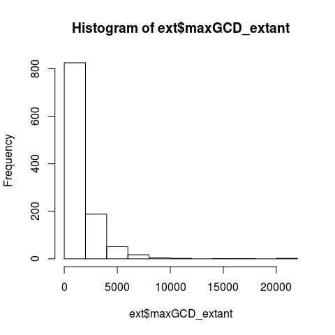

```r
hist(ext$maxGCD_extant)
```

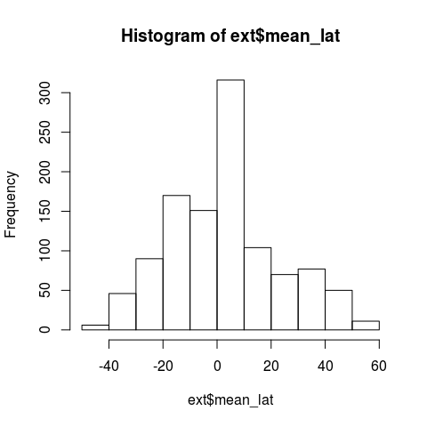

```r
hist(ext$mean_lat)
```

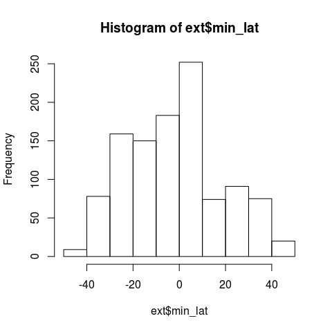

```r
hist(ext$min_lat)
```

1091 complete cases in the data. Body size distribution as expected (follows a negative binomial, cut off at the lower end). Same goes for count data, which is stronger skewed however.

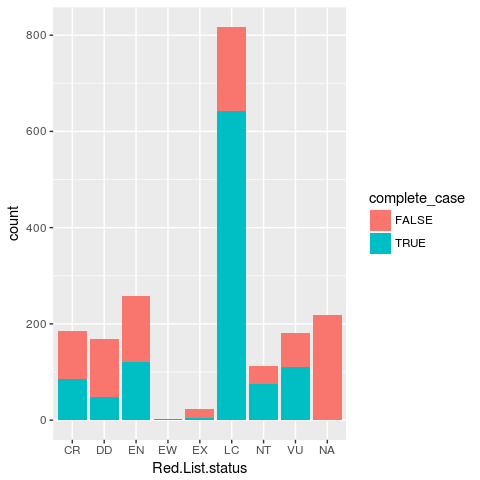

```r
library(ggplot2)
ggplot(extant, aes(Red.List.status, fill=complete_case))+geom_bar()
```

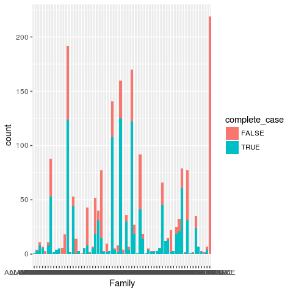

```r
ggplot(extant, aes(Family, fill=complete_case))+geom_bar()
```

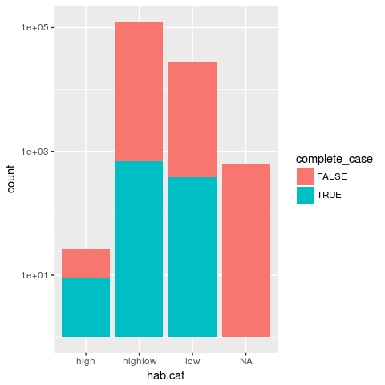

```r
ggplot(extant, aes(hab.cat, fill=complete_case))+geom_bar()+scale_y_log10()#limits = c(0,400), oob = squish)
```

Habitat distribution looks similar to extinct species. Only very few species from high energy habitats only.

# Data comparability

Data from the fossil record and from living species can differ greatly, but also share some common points. Data on geographic ranges, body size and habitat are comparable without further adjustments (?), whereas comparing data on abundance from extinct and living species would be most likely to the disadvantage of the extinct species, caused by the in general low preservation probability of terrestrial organisms. Another variable that is not comparable without further adjustments is extinction risk, wich is defined as species duration in the fossil record, but as category in the IUCN Red List. To bridge these differences between datasets, we chose to categorize data for abundance (mni_max and spec_max) and extinction risk (duration) for the extinct species data.

Applying the fossil data fitted model I will predict duration for extant species, which can be compared to their current assassment categories. Therefore, only abundance categorization has to be done. We regard EW and EX to be of the same results and therefore similar for our approach. DD species is not a category for extinction risk, therefore there is 6 categories for living species, which is in increasing order: LC, NT, VU, EN, CR, and EX.

Abundance in the living dataset comes in 4 categories, which is why we categorize our extinct data the same.

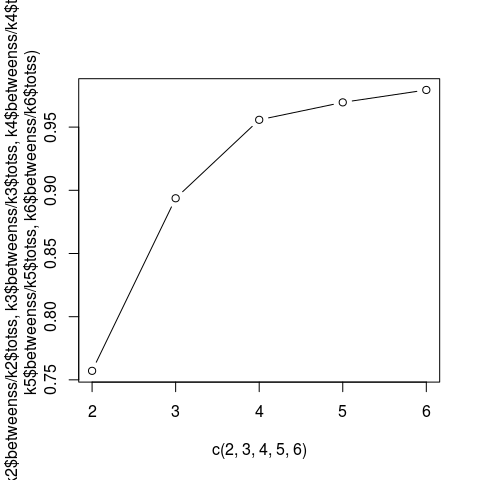

```r
extinct_cc <- extinct[complete.cases(extinct),]

k2 <- kmeans(extinct_cc[, 4:5], 2)
k3 <- kmeans(extinct_cc[, 4:5], 3)
k4 <- kmeans(extinct_cc[, 4:5], 4)
k5 <- kmeans(extinct_cc[, 4:5], 5)
k6 <- kmeans(extinct_cc[, 4:5], 6)

plot(c(2,3,4,5,6),
     c(k2$betweenss/k2$totss, k3$betweenss/k3$totss, k4$betweenss/k4$totss,
     k5$betweenss/k5$totss, k6$betweenss/k6$totss), type="b")
```

Clustering the data (using both specimens and mni values) shows that between sum of squares divided by total SS, as a measure of the goodness of the classification k-means, that there is much improvement increasing the number of clusters from 2 to 3 and from 3 to 4, but not much from 4 clusters on. Using 4 abundance categories is reasonable.

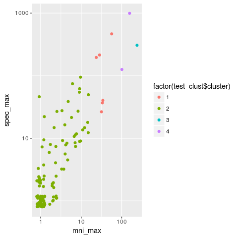

```r
set.seed(20)
mni_cluster <- kmeans(extinct_cc$mni_max, 4)

test_clust <- kmeans(extinct_cc[, 4:5], 4, nstart = 20)
ggplot(extinct_cc, aes(x=mni_max, y=spec_max, col=factor(test_clust$cluster)))+
  geom_jitter(width=.1, height=.1)+
  scale_y_log10()+
  scale_x_log10()
```

```r
# rename clusters to be intuitive
abu_cat <- mni_cluster$cluster
abu_cat[mni_cluster$cluster==order(mni_cluster$centers)[1]] <- 1
abu_cat[mni_cluster$cluster==order(mni_cluster$centers)[2]] <- 2
abu_cat[mni_cluster$cluster==order(mni_cluster$centers)[3]] <- 3
abu_cat[mni_cluster$cluster==order(mni_cluster$centers)[4]] <- 4

extinct_cc <- cbind(extinct_cc, abu_cat)
```

## Variables names

```r
model.data <- extinct_cc[,c("ma_range", "lat_range", "gcd", "svl_pred", "mean_lat", "min_lat", "hab.cat.b", "abu_cat")]
apply.data <- ext[,c("lat.range", "maxGCD_extant", "SVL", "mean_lat", "min_lat", "hab.cat", "abu_cat")]

names(apply.data) <- tail(names(model.data), 7)
```

# Modelling

[figure not shown]

```r
library(effects)
lm1 <- lm(data=model.data, log(ma_range+1) ~ lat_range + gcd + svl_pred + mean_lat + min_lat + hab.cat.b + abu_cat)
plot(all.effects(lm1))
```

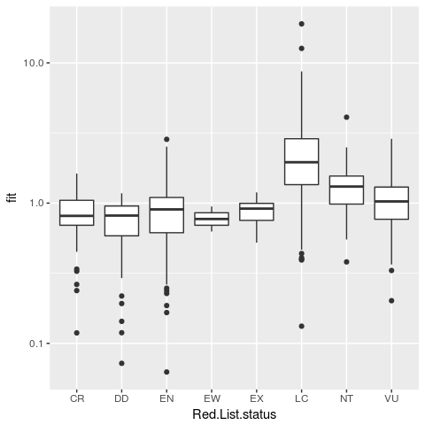

```r
predict.lm1 <- predict.lm(lm1, newdata = apply.data, interval="confidence")

res <- cbind(ext, predict.lm1)

ggplot(res, aes(x=Red.List.status, y=fit))+
  geom_boxplot()+
  scale_y_log10()
```

```r
kruskal.test(res$fit, res$Red.List.status)
```

```
##
##  Kruskal-Wallis rank sum test
##
## data:  res$fit and res$Red.List.status
## Kruskal-Wallis chi-squared = 456.87, df = 7, p-value < 2.2e-16
```

```r
pairwise.wilcox.test(res$fit, res$Red.List.status, p.adjust.method = "fdr")
```

```
##
##  Pairwise comparisons using Wilcoxon rank sum test
##
## data:  res$fit and res$Red.List.status
##
##    CR      DD      EN      EW     EX     LC      NT
## DD 0.1825  -       -       -      -      -       -
## EN 0.8333  0.0778  -       -      -      -       -
## EW 0.7427  0.9796  0.7427  -      -      -       -
## EX 0.9796  0.4648  0.9796  0.9600 -      -       -
## LC < 2e-16 < 2e-16 < 2e-16 0.0643 0.0038 -       -
## NT 5.8e-11 5.8e-11 1.8e-10 0.1220 0.0445 1.5e-11 -
## VU 0.0014  4.2e-05 0.0042  0.4287 0.4648 < 2e-16 6.2e-05
##
## P value adjustment method: fdr
```

Use the median fitted value as the standard duration for this category. Then look which fitted value of a species is closest to the cateogry, assign the category to the species, and make a barplot for “assessed categories”.

```r
res_mean <- tapply(res$fit, res$Red.List.status, median)
library(plyr)
res_mean <- adply(res_mean, 1)
names(res_mean) <- c("cat", "mean")

# Remove extinct + data deficient species
res <- res[!res$Red.List.status %in% c("EW", "EX", "DD"),]
res <- droplevels(res)
res_mean <- res_mean[!res_mean$cat %in% c("EW", "EX", "DD"),]
res_mean <- droplevels(res_mean)

res$Red.List.status_predicted <- rep(NA, nrow(res))
for(i in 1:nrow(res)){
  difference <- abs(res$fit[i] - res_mean$mean)
  res$Red.List.status_predicted[i] <- as.character(res_mean$cat[which.min(difference)])
}
```

Analyse results

```r
matching <- c()
for(i in 1:nrow(res)){
  temp <- res[i,]
  ifelse(temp$Red.List.status==temp$Red.List.status_predicted, matching <- c(matching, TRUE), matching <- c(matching, FALSE))
}
table(matching)
```

```
## matching
## FALSE  TRUE
##   532   504
```

About half of the predictions agrees with the IUCN assessment status. How far off are the other predictions?

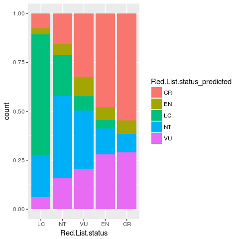

```r
#res$Red.List.status_numeric <- res$Red.List.status
#levels(res$Red.List.status_numeric) <- c(5, 4, 1, 2, 3)
#
#res$Red.List.status_predicted_numeric <- as.factor(res$Red.List.status_predicted)
#levels(res$Red.List.status_predicted_numeric) <- c(5, 4, 1, 2, 3)

res$Red.List.status <- ordered(res$Red.List.status, levels = c("LC", "NT", "VU", "EN", "CR"))
ggplot(res, aes(Red.List.status, fill=Red.List.status_predicted))+
    geom_bar(position = "fill")
```

Plot shows that the predicted category is always most prevalent in the assessed category, except EN + VU. Check some of the wrongest predictions manually:

```r
res[res$Red.List.status=="CR" & res$Red.List.status_predicted=="NT",]
```

```
##       X.1    X                    species        SVL abu_cat lat.range
## 40     40   40           Agalychnis lemur 0.03386693       3  3.128857
## 203   203  203        Atelopus bomolochos 0.04432103       3  2.359684
## 214   214  214           Atelopus elegans 0.02482849       4  3.943583
## 243   243  243         Atelopus peruensis 0.03190678       4  3.444348
## 252   252  252         Atelopus simulatus 0.02134379       3  3.034605
## 258   258  258            Atelopus varius 0.03152565       3  2.618029
## 627   627  627 Eleutherodactylus schmidti 0.05259719       3  1.207357
## 1122 1122 1122        Litoria nyakalensis 0.02373952       3  2.380123
##      maxGCD_extant   mean_lat min_lat Red.List.status Order
## 40        939.6052   9.562143    7.90              CR ANURA
## 203       248.8570  -1.951489   -3.98              CR ANURA
## 214       458.9905   1.456400   -0.94              CR ANURA
## 243       470.2627  -7.919200   -9.31              CR ANURA
## 252       401.1395   2.644074    1.60              CR ANURA
```

[output cut: 21 more lines]

*Agalychnis lemur* has suffered from drastig population declines over the last 10 years, probably Bd. *Atelopus bomolochos* population decline through Bd. *Atelopus elegans* drastic decline, unexplained (Bd?). *Atelopus peruensis* and *Atelopus simulatus* *Atelopus varius* *Eleutherodactylus schmidti* *Litoria nyakalensis* the same

All species used to be very abundant (and were categorized as category 3 or 4), but declined rapidly over the last years.